# Project 2:Investigate no show medical appointments in Brazil

### Introduction

In this project we investigate a dataset of 100K medical appointments in Brazil. The dataset contains various characteristics for each patient and whether or not he showed up to the appointment. Exploring the data we aim to answer the following questions: 1) Which is the show up and no-show rate, for the given dataset? 2) Does waiting time and SMS receipt affect show or no show to an appointment? 3) Are there any specific attributes,like for example age and gender, influence no shows?

#### Importing python packages and the dataset

```python
import matplotlib.pyplot as plt
import numpy as np
import pandas as pd
import seaborn as sns
import datetime
import collections
import statsmodels.stats.proportion
%matplotlib inline
```

```python
no_show=pd.read_csv(r"C:\Users\Dora\Documents\Dora back up\Nanodegree_Udacity\noshowappointments.csv")
```

## 1.Data Wrangling

#### Explore the data and find possible discrepancies

```python
#View of the data fields
no_show.head()
```

|  | PatientId | AppointmentID | Gender | ScheduledDay | AppointmentDay | Age | Neighbourhood | Scholarship | Hipertension | Diabetes | Alcoholism | Handcap | SMS_received | No-show |
| --- | --- | --- | --- | --- | --- | --- | --- | --- | --- | --- | --- | --- | --- | --- |
| 0 | 2.987250e+13 | 5642903 | F | 2016-04-29T18:38:08Z | 2016-04-29T00:00:00Z | 62 | JARDIM DA PENHA | 0 | 1 | 0 | 0 | 0 | 0 | No |
| 1 | 5.589978e+14 | 5642503 | M | 2016-04-29T16:08:27Z | 2016-04-29T00:00:00Z | 56 | JARDIM DA PENHA | 0 | 0 | 0 | 0 | 0 | 0 | No |
| 2 | 4.262962e+12 | 5642549 | F | 2016-04-29T16:19:04Z | 2016-04-29T00:00:00Z | 62 | MATA DA PRAIA | 0 | 0 | 0 | 0 | 0 | 0 | No |
| 3 | 8.679512e+11 | 5642828 | F | 2016-04-29T17:29:31Z | 2016-04-29T00:00:00Z | 8 | PONTAL DE CAMBURI | 0 | 0 | 0 | 0 | 0 | 0 | No |
| 4 | 8.841186e+12 | 5642494 | F | 2016-04-29T16:07:23Z | 2016-04-29T00:00:00Z | 56 | JARDIM DA PENHA | 0 | 1 | 1 | 0 | 0 | 0 | No |

```python
no_show.info()
```

```
<class 'pandas.core.frame.DataFrame'>
RangeIndex: 110527 entries, 0 to 110526
Data columns (total 14 columns):
PatientId         110527 non-null float64
AppointmentID     110527 non-null int64
Gender            110527 non-null object
ScheduledDay      110527 non-null object
AppointmentDay    110527 non-null object
Age               110527 non-null int64
Neighbourhood     110527 non-null object
Scholarship       110527 non-null int64
Hipertension      110527 non-null int64
Diabetes          110527 non-null int64
Alcoholism        110527 non-null int64
Handcap           110527 non-null int64
SMS_received      110527 non-null int64
No-show           110527 non-null object
dtypes: float64(1), int64(8), object(5)
memory usage: 11.8+ MB
```

```python
## Data Summary
no_show.describe()
```

|  | PatientId | AppointmentID | Age | Scholarship | Hipertension | Diabetes | Alcoholism | Handcap | SMS_received |
| --- | --- | --- | --- | --- | --- | --- | --- | --- | --- |
| count | 1.105270e+05 | 1.105270e+05 | 110527.000000 | 110527.000000 | 110527.000000 | 110527.000000 | 110527.000000 | 110527.000000 | 110527.000000 |
| mean | 1.474963e+14 | 5.675305e+06 | 37.088874 | 0.098266 | 0.197246 | 0.071865 | 0.030400 | 0.022248 | 0.321026 |
| std | 2.560949e+14 | 7.129575e+04 | 23.110205 | 0.297675 | 0.397921 | 0.258265 | 0.171686 | 0.161543 | 0.466873 |
| min | 3.921784e+04 | 5.030230e+06 | -1.000000 | 0.000000 | 0.000000 | 0.000000 | 0.000000 | 0.000000 | 0.000000 |
| 25% | 4.172614e+12 | 5.640286e+06 | 18.000000 | 0.000000 | 0.000000 | 0.000000 | 0.000000 | 0.000000 | 0.000000 |
| 50% | 3.173184e+13 | 5.680573e+06 | 37.000000 | 0.000000 | 0.000000 | 0.000000 | 0.000000 | 0.000000 | 0.000000 |
| 75% | 9.439172e+13 | 5.725524e+06 | 55.000000 | 0.000000 | 0.000000 | 0.000000 | 0.000000 | 0.000000 | 1.000000 |
| max | 9.999816e+14 | 5.790484e+06 | 115.000000 | 1.000000 | 1.000000 | 1.000000 | 1.000000 | 4.000000 | 1.000000 |

```python
##No of unique patients in the dataset
no_show['PatientId'].nunique()
```

```
62299
```

The above means that some patiends had booked an apointment more than one time.

Some columns in the dataset have spelling errors. Below, we will rename the columns.

```python
## Rename columns-fix spelling erros
no_show.columns = [
    'Patient_ID', 'Appointment_ID', 'Gender', 'Scheduled_day',
    'Appointment_day', 'Age', 'Neighbourhood', 'Scholarship',
    'Hypertension', 'Diabetes', 'Alcoholism', 'Handicap', 'SMS_received',
    'no_show'
    ]
```

```python
## See the changes
no_show.info()
```

```
<class 'pandas.core.frame.DataFrame'>
RangeIndex: 110527 entries, 0 to 110526
Data columns (total 14 columns):
Patient_ID         110527 non-null float64
Appointment_ID     110527 non-null int64
Gender             110527 non-null object
Scheduled_day      110527 non-null object
Appointment_day    110527 non-null object
Age                110527 non-null int64
Neighbourhood      110527 non-null object
Scholarship        110527 non-null int64
Hypertension       110527 non-null int64
Diabetes           110527 non-null int64
Alcoholism         110527 non-null int64
Handicap           110527 non-null int64
SMS_received       110527 non-null int64
no_show            110527 non-null object
dtypes: float64(1), int64(8), object(5)
memory usage: 11.8+ MB
```

Scheduled_day and Appointment_day have been saved as objects. Since those two metrics are dates,we need to convert them from string to Datetime.

```python
##Convert scheduled_day and appointment day from string to Datetime
no_show.Scheduled_day=pd.to_datetime(no_show.Scheduled_day)
no_show.Appointment_day=pd.to_datetime(no_show.Appointment_day)
type([no_show.Scheduled_day])
no_show.info()
print(no_show['Scheduled_day'].max())
print(no_show['Scheduled_day'].min())
```

```
<class 'pandas.core.frame.DataFrame'>
RangeIndex: 110527 entries, 0 to 110526
Data columns (total 14 columns):
Patient_ID         110527 non-null float64
Appointment_ID     110527 non-null int64
Gender             110527 non-null object
Scheduled_day      110527 non-null datetime64[ns, UTC]
Appointment_day    110527 non-null datetime64[ns, UTC]
Age                110527 non-null int64
Neighbourhood      110527 non-null object
Scholarship        110527 non-null int64
Hypertension       110527 non-null int64
Diabetes           110527 non-null int64
Alcoholism         110527 non-null int64
Handicap           110527 non-null int64
SMS_received       110527 non-null int64
no_show            110527 non-null object
dtypes: datetime64[ns, UTC](2), float64(1), int64(8), object(3)
memory usage: 11.8+ MB
2016-06-08 20:07:23+00:00
2015-11-10 07:13:56+00:00
```

Lead days is an important metric for our later analysis. So we need to calculate Lead days until the appointment and save it in a correct data type.

```python
def get_date(datetime_object):
    '''This function returns the date part of a datetime'''
    return datetime_object.date()

## Calculate Lead Time From the scheduled appointment till appointment date/ timedelta64[ns] format
no_show['Lead_days'] = (
    no_show.Appointment_day.apply(get_date)
    - no_show.Scheduled_day.apply(get_date)
    )
# Transform Lead_days as integer
#no_show['Lead_days']=no_show['Lead_days']/timedelta (days=1)
no_show.Lead_days = (
    (no_show.Lead_days.astype('timedelta64[D]')).astype(int)
    )

no_show['Lead_days'].describe()
```

```
count    110527.000000
mean         10.183702
std          15.254996
min          -6.000000
25%           0.000000
50%           4.000000
75%          15.000000
max         179.000000
Name: Lead_days, dtype: float64
```

We convert Scholardhip,Diabetes,Hypertension,Alcoholism,SMS_received fields to boolean type,because it is easier to analyze them later.

```python
## Convert scholardhip,Diabetes,Hypertension,Alcoholism,SMS_received to boolean type
boolean_col=["Alcoholism","Diabetes","Hypertension","SMS_received","Scholarship"]

for i in boolean_col:
    no_show[i] = no_show[i].astype("bool")
no_show.info()
```

```
<class 'pandas.core.frame.DataFrame'>
RangeIndex: 110527 entries, 0 to 110526
Data columns (total 15 columns):
Patient_ID         110527 non-null float64
Appointment_ID     110527 non-null int64
Gender             110527 non-null object
Scheduled_day      110527 non-null datetime64[ns, UTC]
Appointment_day    110527 non-null datetime64[ns, UTC]
Age                110527 non-null int64
Neighbourhood      110527 non-null object
Scholarship        110527 non-null bool
Hypertension       110527 non-null bool
Diabetes           110527 non-null bool
Alcoholism         110527 non-null bool
Handicap           110527 non-null int64
SMS_received       110527 non-null bool
no_show            110527 non-null object
Lead_days          110527 non-null int32
dtypes: bool(5), datetime64[ns, UTC](2), float64(1), int32(1), int64(3), object(3)
memory usage: 8.5+ MB
```

In order to convert Handicap to bool type, we first need to identify whether or not the patient is handicapped

```python
##  Handicap has values from 0-4, as it describes the number of handicaps. We care only if the patient is handicapped or not.

no_show['Handicap'] = np.where(no_show['Handicap']==0, 0, 1)

no_show['Handicap'] = no_show['Handicap'].astype("bool")
no_show.info()
```

```
<class 'pandas.core.frame.DataFrame'>
RangeIndex: 110527 entries, 0 to 110526
Data columns (total 15 columns):
Patient_ID         110527 non-null float64
Appointment_ID     110527 non-null int64
Gender             110527 non-null object
Scheduled_day      110527 non-null datetime64[ns, UTC]
Appointment_day    110527 non-null datetime64[ns, UTC]
Age                110527 non-null int64
Neighbourhood      110527 non-null object
Scholarship        110527 non-null bool
Hypertension       110527 non-null bool
Diabetes           110527 non-null bool
Alcoholism         110527 non-null bool
Handicap           110527 non-null bool
SMS_received       110527 non-null bool
no_show            110527 non-null object
Lead_days          110527 non-null int32
dtypes: bool(6), datetime64[ns, UTC](2), float64(1), int32(1), int64(2), object(3)
memory usage: 7.8+ MB
```

```python
## Following the same format we convert the No-show column to Boolean

#no_show.no_show.replace({'Yes':True,'No':False}, inplace=True)

no_show.info()
```

```
<class 'pandas.core.frame.DataFrame'>
RangeIndex: 110527 entries, 0 to 110526
Data columns (total 15 columns):
Patient_ID         110527 non-null float64
Appointment_ID     110527 non-null int64
Gender             110527 non-null object
Scheduled_day      110527 non-null datetime64[ns, UTC]
Appointment_day    110527 non-null datetime64[ns, UTC]
Age                110527 non-null int64
Neighbourhood      110527 non-null object
Scholarship        110527 non-null bool
Hypertension       110527 non-null bool
Diabetes           110527 non-null bool
Alcoholism         110527 non-null bool
Handicap           110527 non-null bool
SMS_received       110527 non-null bool
no_show            110527 non-null object
Lead_days          110527 non-null int32
dtypes: bool(6), datetime64[ns, UTC](2), float64(1), int32(1), int64(2), object(3)
memory usage: 7.8+ MB
```

Creating Histogram, in order to find the right Lead time bins

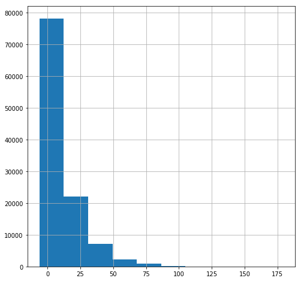

```python
# Distribution of the lead days column, in order to create the right batches

no_show['Lead_days'].hist(figsize=(8,8))
```

We odserve that there are negative values for the metric "lead days".This is impossible, since every appointment is in the future.

```python
#We remove the rows from the dataset, containing negative lead time.

no_show = (no_show.drop(no_show[no_show.Lead_days < 0].index))
no_show.describe()
```

|  | Patient_ID | Appointment_ID | Age | Lead_days |
| --- | --- | --- | --- | --- |
| count | 1.105220e+05 | 1.105220e+05 | 110522.000000 | 110522.000000 |
| mean | 1.474935e+14 | 5.675305e+06 | 37.089041 | 10.184253 |
| std | 2.560866e+14 | 7.129722e+04 | 23.110064 | 15.255115 |
| min | 3.921784e+04 | 5.030230e+06 | -1.000000 | 0.000000 |
| 25% | 4.172536e+12 | 5.640284e+06 | 18.000000 | 0.000000 |
| 50% | 3.173700e+13 | 5.680574e+06 | 37.000000 | 4.000000 |
| 75% | 9.439277e+13 | 5.725525e+06 | 55.000000 | 15.000000 |
| max | 9.999816e+14 | 5.790484e+06 | 115.000000 | 179.000000 |

```python
# Binning Lead Days
bins=[-1,0,3,7,25,170]
#Create Labels

no_show["Lead_days_group"]=pd.cut(no_show.Lead_days,bins,labels=['A.Same Day','B.1-3 Days','C.4-7 Days','D.8-25 Days','E.25+ Days'])
```

```
1
7
```

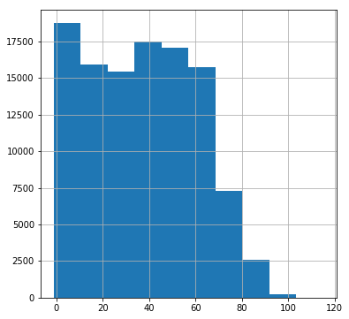

```python
no_show['Age'].hist(figsize=(6,6))
print(len(no_show[no_show['Age']<0]))
print(len(no_show[no_show['Age']>100]))
```

It seems that there are negative values in the age field, which is impossible. Also, some rare values are shown (Age>=100). Due to the fact that these values are very few, and it is in not impossible someone be 110, we keep the values.

```python
#Drop negative age from the dataset
no_show = (no_show.drop(no_show[no_show.Age < 0].index))
no_show.describe()
```

|  | Patient_ID | Appointment_ID | Age | Lead_days |
| --- | --- | --- | --- | --- |
| count | 1.105210e+05 | 1.105210e+05 | 110521.000000 | 110521.000000 |
| mean | 1.474906e+14 | 5.675304e+06 | 37.089386 | 10.184345 |
| std | 2.560860e+14 | 7.129691e+04 | 23.109885 | 15.255153 |
| min | 3.921784e+04 | 5.030230e+06 | 0.000000 | 0.000000 |
| 25% | 4.172457e+12 | 5.640284e+06 | 18.000000 | 0.000000 |
| 50% | 3.173185e+13 | 5.680573e+06 | 37.000000 | 4.000000 |
| 75% | 9.438963e+13 | 5.725524e+06 | 55.000000 | 15.000000 |
| max | 9.999816e+14 | 5.790484e+06 | 115.000000 | 179.000000 |

## 2.Exploring Data

#### Question 1: Which is the overall Show and No show Rate?

```
No     88207
Yes    22314
Name: no_show, dtype: int64
```

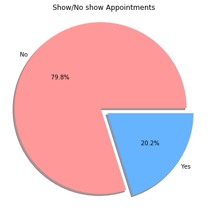

```python
# Plot a pie chart for no show counts

pie_data = no_show.no_show.value_counts()
print(pie_data)

label_list = pie_data.index
sizes = pie_data
explode_list = (0.1, 0)
fig1, ax1 = plt.subplots(figsize=(6, 6))
colors = ['#ff9999','#66b3ff']
ax1.pie(
    sizes, explode = explode_list,colors=colors, labels = label_list, autopct =' %1.1f%%',
    pctdistance = 0.6, labeldistance = 1.05, shadow = True, startangle = 0,
    )

ax1.axis('equal')
ax1.set_title('Show/No show Appointments')
plt.show()
```

From 110521 schedulled appointments,22314 appointments missed (20,2%).

### Question 2: Does waiting time and SMS receipt affect show or no show to an appointment?

Creating a bar chart presenting no show rate per lead days categories.

```
Lead_days_group
A.Same Day     38562
B.1-3 Days     14675
C.4-7 Days     17510
D.8-25 Days    24153
E.25+ Days     15595
Name: no_show, dtype: int64 Lead_days_group
A.Same Day     1792.0
B.1-3 Days     3359.0
C.4-7 Days     4413.0
D.8-25 Days    7696.0
E.25+ Days     5046.0
Name: Missed, dtype: float64
22314
20.18982817745044
Lead_days_group
A.Same Day      4.647062
B.1-3 Days     22.889267
C.4-7 Days     25.202741
D.8-25 Days    31.863537
E.25+ Days     32.356525
dtype: float64
```

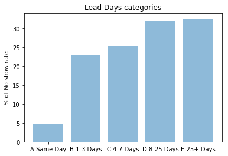

```python
No_of_no_show = no_show["no_show"].value_counts()
No_of_no_show=No_of_no_show.loc["Yes"]
no_show_rate = (No_of_no_show/len(no_show["no_show"]))*100
no_show['Missed'] = no_show['no_show'].apply(lambda x: x >= 'Yes')

b=no_show.groupby('Lead_days_group').sum()['Missed']
c=no_show.groupby('Lead_days_group').count()['no_show']

No_show_rate_per_Lead_Time=(b/c)*100


print(c,b)
#Total number of missed appointments
print(No_of_no_show)
#Total No show Rate
print(no_show_rate)
#No show rate per Lead Categories
print(No_show_rate_per_Lead_Time)

objects =['A.Same Day','B.1-3 Days','C.4-7 Days','D.8-25 Days','E.25+ Days']


y_pos = np.arange(len(objects))


plt.bar(y_pos, No_show_rate_per_Lead_Time, align='center', alpha=0.5)
plt.xticks(y_pos, objects)
plt.ylabel('% of No show rate')
plt.title('Lead Days categories')

plt.show()
```

From the graph we observe that no show rate is higher in patients with higher lead time. Specifically, patients waiting over 8 days, have a 32% no show rate.Same day appointments have low no show rate (4,65%).

Another way to support the idea that Lead days affect show or no show is finding the corellation between Lead days and missed appointments.

```python
#Find correlation between Missed appointments and the other metrics '''
no_show.corr()
```

|  | Patient_ID | Appointment_ID | Age | Scholarship | Hypertension | Diabetes | Alcoholism | Handicap | SMS_received | Lead_days | Missed |
| --- | --- | --- | --- | --- | --- | --- | --- | --- | --- | --- | --- |
| Patient_ID | 1.000000 | 0.004019 | -0.004192 | -0.002873 | -0.006431 | 0.001612 | 0.011016 | -0.008590 | -0.009735 | -0.001442 | -0.001477 |
| Appointment_ID | 0.004019 | 1.000000 | -0.019109 | 0.022620 | 0.012760 | 0.022633 | 0.032947 | 0.015094 | -0.256614 | -0.771840 | -0.162619 |
| Age | -0.004192 | -0.019109 | 1.000000 | -0.092469 | 0.504599 | 0.292398 | 0.095811 | 0.083827 | 0.012629 | 0.034813 | -0.060320 |
| Scholarship | -0.002873 | 0.022620 | -0.092469 | 1.000000 | -0.019738 | -0.024899 | 0.035019 | -0.009068 | 0.001182 | -0.030435 | 0.029166 |
| Hypertension | -0.006431 | 0.012760 | 0.504599 | -0.019738 | 1.000000 | 0.433082 | 0.087967 | 0.084949 | -0.006285 | -0.017236 | -0.035662 |
| Diabetes | 0.001612 | 0.022633 | 0.292398 | -0.024899 | 0.433082 | 1.000000 | 0.018471 | 0.059204 | -0.014561 | -0.027200 | -0.015158 |
| Alcoholism | 0.011016 | 0.032947 | 0.095811 | 0.035019 | 0.087967 | 0.018471 | 1.000000 | 0.003715 | -0.026154 | -0.038527 | -0.000181 |
| Handicap | -0.008590 | 0.015094 | 0.083827 | -0.009068 | 0.084949 | 0.059204 | 0.003715 | 1.000000 | -0.025148 | -0.020885 | -0.007528 |
| SMS_received | -0.009735 | -0.256614 | 0.012629 | 0.001182 | -0.006285 | -0.014561 | -0.026154 | -0.025148 | 1.000000 | 0.398128 | 0.126502 |
| Lead_days | -0.001442 | -0.771840 | 0.034813 | -0.030435 | -0.017236 | -0.027200 | -0.038527 | -0.020885 | 0.398128 | 1.000000 | 0.186320 |
| Missed | -0.001477 | -0.162619 | -0.060320 | 0.029166 | -0.035662 | -0.015158 | -0.000181 | -0.007528 | 0.126502 | 0.186320 | 1.000000 |

However lead time seems to affect the result, correlation between lead days and missed appointments is weak.

```python
# Does receiving SMS improve the no_show rate?
#When patients receive SMS?

SMS_received_lead_days=no_show.groupby(['Lead_days','SMS_received']).size()

print(SMS_received_lead_days)
```

```
Lead_days  SMS_received
0          False           38562
1          False            5213
2          False            6725
3          False            1831
           True              906
4          False            2236
           True             3054
5          False            1223
           True             2054
6          False            1353
           True             2684
7          False            2056
           True             2850
8          False             892
           True             1440
9          False             608
           True              997
10         False             693
           True              698
11         False             505
           True              482
12         False             451
           True              664
13         False             652
           True             1030
14         False            1220
           True             1693
15         False             580
           True              923
16         False             427
                           ...
110        False               1
           True                1
111        False               1
           True                4
112        False               3
           True                2
115        True                2
117        True                1
```

[output cut: 8 more lines]

```
133        False              11
139        True                1
142        True                8
146        True                1
151        True                1
155        False               1
           True                9
162        False              11
169        False               1
           True                7
176        False               3
           True               13
179        False               3
           True                7
Length: 234, dtype: int64
```

The patient receives SMS, only if the appointment has been scheduled after 3 days. Same day appointments have low no show rate, as a result we will take the appointments scheduled after 3 days, in order to avoid misleading results.

```python
#Data for appointments with Lead days higher than 3 days
Lead_days_3plus=no_show[no_show.Lead_days>3]

b1=Lead_days_3plus.groupby(['SMS_received','Lead_days_group']).size()


y=Lead_days_3plus.groupby(['Lead_days_group','SMS_received']).sum()['Missed']

#print(y)

x=Lead_days_3plus.groupby(['Lead_days_group','SMS_received']).count()['no_show']

No_show_rate_per_LT_SMS=(y/x)*100
print(No_show_rate_per_LT_SMS)
```

```
Lead_days_group  SMS_received
A.Same Day       False                 NaN
                 True                  NaN
B.1-3 Days       False                 NaN
                 True                  NaN
C.4-7 Days       False           27.111241
                 True            23.971058
D.8-25 Days      False           35.682249
                 True            29.150142
E.25+ Days       False           36.683330
                 True            29.793751
dtype: float64
```

Receiving SMS reduces no-show rate in all Lead categories.Especially,in the category E.25+ days, receiving SMS improves no show rate about 6pp (29,8%).

### Question 3: Are there specific attributes, like age or gender that influence no shows?

```
Gender
F    14591.0
M     7723.0
Name: Missed, dtype: float64
Gender
F    71836
M    38685
Name: no_show, dtype: int64
Gender
F    20.311543
M    19.963810
dtype: float64
```

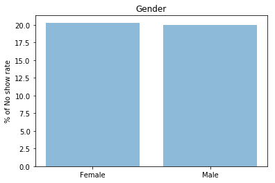

```python
#Does the gender play role in missed appointmets?
objects2 =['Female','Male']

d=no_show.groupby('Gender').sum()['Missed']
print(d)
e=no_show.groupby('Gender').count()['no_show']
print(e)
No_show_rate_per_gender=(d/e)*100
print(No_show_rate_per_gender)

y_pos = np.arange(len(objects2))


plt.bar(y_pos, No_show_rate_per_gender, align='center', alpha=0.5)
plt.xticks(y_pos, objects2)
plt.ylabel('% of No show rate')
plt.title('Gender')

plt.show()
```

Both genders tend miss the appointments at ~20%. Consequently, gender seems not to influence show or no show.

```
Age_Groups
A.0-12     4609.0
B.13-17    1737.0
C.18-24    2469.0
D.25-34    3282.0
E.35-49    4491.0
F.50-64    3661.0
G.65+      2065.0
Name: Missed, dtype: float64
Age_Groups
A.0-12     22138
B.13-17     6727
C.18-24     9731
D.25-34    14404
E.35-49    22099
F.50-64    22122
G.65+      13300
Name: no_show, dtype: int64
Age_Groups
A.0-12     20.819406
B.13-17    25.821317
C.18-24    25.372521
D.25-34    22.785337
E.35-49    20.322187
F.50-64    16.549137
G.65+      15.526316
dtype: float64
```

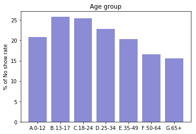

```python
#Examine if age affect the show or no show.
 #Create age groups
bins=[-1,13,18,25,35,50,65,200]
#Create Labels

no_show["Age_Groups"]=pd.cut(no_show.Age,bins,labels=['A.0-12','B.13-17','C.18-24','D.25-34','E.35-49','F.50-64','G.65+'])

AgeList =['A.0-12','B.13-17','C.18-24','D.25-34','E.35-49','F.50-64','G.65+']

f=no_show.groupby('Age_Groups').sum()['Missed']
print(f)
g=no_show.groupby('Age_Groups').count()['no_show']
print(g)
No_show_rate_per_age_group=(f/g)*100
print(No_show_rate_per_age_group)

y_pos = np.arange(len(AgeList))


plt.bar(y_pos, No_show_rate_per_age_group, align='center', alpha=0.6, color=('#3E40B9'))
plt.xticks(y_pos, AgeList)
plt.ylabel('% of No show rate')
plt.title('Age group')

plt.show()
```

For the age group 13-17 and 18-24 the percentage of no show in an appointment is higher than in the other age groups. For the age group 50-64 and 65+, the rate is 16,5% and 15,5% respectively, which is 10pp lower than the percentage of younger ages.

```python
#Scholarship. Does patients with scholarship keep the appointments?
```

```
Scholarship
False    19736.0
True      2578.0
Name: Missed, dtype: float64
Scholarship
False    99660
True     10861
Name: no_show, dtype: int64
Scholarship
False    19.803331
True     23.736304
dtype: float64
```

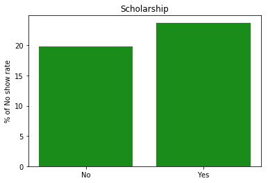

```python
#False comes first, from True-- Alphabetically
Scholarship_list =['No','Yes']

S=no_show.groupby('Scholarship').sum()['Missed']
print(S)
T=no_show.groupby('Scholarship').count()['no_show']
print(T)
No_show_rate_Scholarship=(S/T)*100
print(No_show_rate_Scholarship)

y_s = np.arange(len(Scholarship_list))


plt.bar(y_s, No_show_rate_Scholarship, align='center', alpha=0.9,color='Green')
plt.xticks(y_s, Scholarship_list)
plt.ylabel('% of No show rate')
plt.title('Scholarship')

plt.show()
```

Patiens with Scholarship seems to miss doctor appointments more easily.

## References

- https://www.kaggle.com/alfrednfwong/eda-no-shows-at-brazil-medical-appointments
- https://github.com/samedhaa/investigating-a-dataset-no-show-appointments-udacity/blob/master/exploring-noShowAppointments-Dataset.ipynb
- https://github.com/AmmarJawad/No-show-Medical-Appointments_Kaggle-dataset/blob/master/project_submission.ipynb